# tp

```python
import numpy as np
import matplotlib.pyplot as plt
```

## Exercice 1.

### a.

[figure not shown]

### b.

[figure not shown]

## Exercice 2.

### a.

$(E_1)$ donne $y(0)=1$ donc dans le schmé d'Euler correspondant $y_0=1$. Par ailleurs on a $y'(t)=y(t)$ d'où $y'(t)=f(y(t))$ avec $f(t)=t$. Donc dans le schéma d'Euler correspondant $y_{n+1} = y_n + h*f(y_n)=y_n + hy_n$

### b.

Je vais directement le faire en python.

### c.

Plutôt que de refaire un algorithme à chaque question je vais faire un algorithme générique qui mange la fonction $f$, un point de depart $y_0$ un intervalle $[a,b]$ et un nombre de subdivisions $N$.

```python
def euler(N, a, b, f, y0):
    h=(b-a)/N
    Lt=[a + i*h for i in range(N+1)]
    y=[y0]
    for i in range(1, N+1):
        yi=y[i-1]+h*f(y[i-1])
        y.append(yi)
    plt.plot(Lt, y, label=f"Pour n={N}")
    return y
```

Et pour notre cas précis :

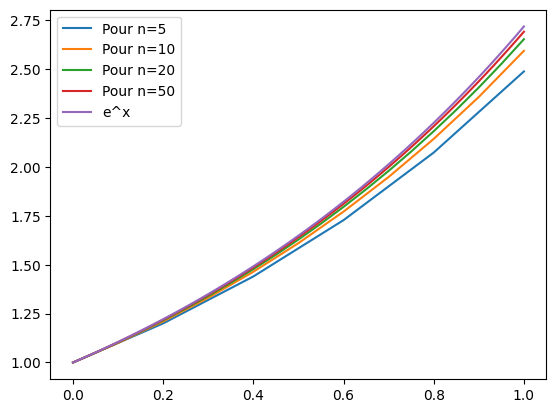

```python
def f(x):
    return x

def vrai_solution(x):
    return np.exp(x)

a=0
b=1
y0=1

plt.clf() #On nettoie au cas où
for N in [5, 10, 20, 50]: #on fait tout les cas de N possibles
    euler(N, a,b,f,y0)#on fait euler pour tout les N


#On fait maintenant une autre subdivision pour afficher la vrai solution
N=50
h=h=(b-a)/N
Lt_vrai=[a + i*h for i in range(N+1)]
plt.plot(Lt_vrai, [vrai_solution(x) for x in Lt_vrai], label="e^x")

plt.legend()#Affiche des legendes
plt.show()#affiche le graphe
```

## Exercice 3.

### a.

$(E_2)$ donne $y(0)=1$ donc dans le schéma d'Euler correspondant $y_0=1$. Par ailleurs on a $y'(t)=-y((t))^2$ d'où $y'(t)=f(y(t))$ avec $f(t)=-t^2$. Donc dans le schéma d'Euler correspondant $y_{n+1} = y_n + h*f(y_n)=y_n - hy_n^2$

### b.

Je préfère directement faire le python.

### c.

Comme toutes les fonctions sont déjà faites il suffit de modifier les valeurs de l'exo d'avant

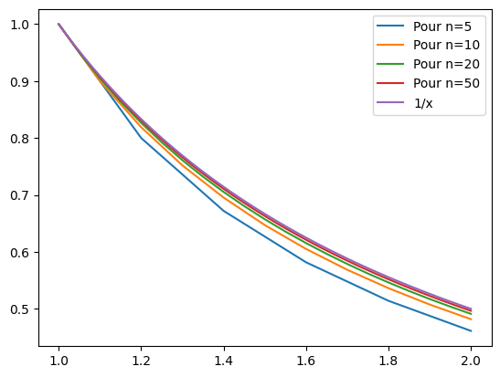

```python
def f(x):
    return -x**2

def vrai_solution(x):
    return 1/x

a=1
b=2
y0=1

plt.clf() #On nettoie au cas où
for N in [5, 10, 20, 50]: #on fait tout les cas de N possibles
    euler(N, a,b,f,y0)#on fait euler pour tout les N


#On fait maintenant une autre subdivision pour afficher la vrai solution
N=50
h=h=(b-a)/N
Lt_vrai=[a + i*h for i in range(N+1)]
plt.plot(Lt_vrai, [vrai_solution(x) for x in Lt_vrai], label="1/x")

plt.legend()#Affiche des legendes
plt.show()#affiche le graphe
```

## Exercice 4.

### a.

$(E_3)$ donne $q(0)=0$ donc dans le schéma d'Euler correspondant $q_0=0$. Par ailleurs on a $q'(t)=\frac{V_{in}}{R}-\frac{q}{RC}$ d'où $q'(t)=f(q(t))$ avec $f(t)=\frac{V_{in}}{R}-\frac{x}{RC}$. Donc dans le schéma d'Euler correspondant $q_{n+1} = q_n + h*q(y_n)=y_n + h * (\frac{V_{in}}{R}-\frac{q_n}{RC})$

### b.

Je préfère directement faire le python.

### c.

Comme toutes les fonctions sont déjà faites il suffit de modifier les valeurs de l'exo d'avant

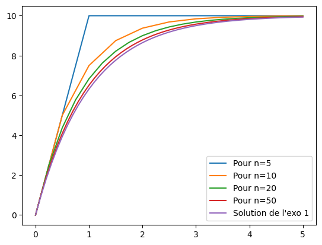

```python
R=1
C=1
Vin=10

def f(x):
    res = Vin/R - x/(R*C)
    return res

def vrai_solution(x):
    res = 10 - 10 *np.exp(-x)
    return res

a=0
b=5
q0=0

plt.clf() #On nettoie au cas où
for N in [5, 10, 20, 50]: #on fait tout les cas de N possibles
    euler(N, a,b,f,q0)#on fait euler pour tout les N


#On fait maintenant une autre subdivision pour afficher la vrai solution
N=50
h=h=(b-a)/N
Lt_vrai=[a + i*h for i in range(N+1)]
plt.plot(Lt_vrai, [vrai_solution(x) for x in Lt_vrai], label="Solution de l'exo 1")

plt.legend()#Affiche des legendes
plt.show()#affiche le graphe
```

## Exercice 5.

### a.

Déjà on met tout en m/s pour pas se perdre et on a $v_{lim} = 55.6 m/s$

On part du principe que à la vitesse limite l'accélération est nulle alors on a $k_2*v_{lim}^2=m*g$ et donc $k_2=\frac{m*g}{v_{lim}^2}\approx \frac{80*9.81}{55.6^2}=0.254 kg/m$

### b.

En $t=0$ le parachutiste a une vitesse nulle alors $v(0)=0$ et on pose $v_0=0$. On a aussi $v'(t)= f(v(t))$ avec $f(t)=g- \frac{k_2}{m}*t^2$ donc on pose $v_{n+1}=v_n +h*f(v_n)$

### c.

Comme toutes les fonctions sont déjà faites il suffit de modifier les valeurs de l'exo d'avant

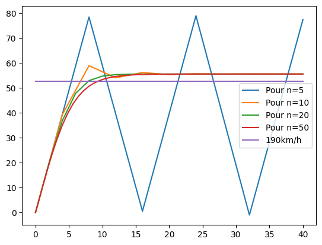

```python
m=80
g=9.81
k2=0.254
vlim=55.6

def f(x):
    res = g-x**2 * (k2/m)
    return res


a=0
b=40
v0=0

plt.clf() #On nettoie au cas où
for N in [5, 10, 20, 50]: #on fait tout les cas de N possibles
    euler(N, a,b,f,v0)#on fait euler pour tout les N

#On fait maintenant une autre subdivision pour afficher 190 km/h
N=50
h=h=(b-a)/N
Lt_vrai=[a + i*h for i in range(N+1)]
plt.plot(Lt_vrai, [52.78 for x in Lt_vrai], label="190km/h")


plt.legend()#Affiche des legendes
plt.show()#affiche le graphe
```

### d.

On peut déjà constater que pour n=5 le schéma n'est pas précis du tout. Cependant à partir de n=10 la convergence est claire.

### e.

Sur le graphe tout est en mêtre par seconde alors il faut regarder quand est ce que le corps atteint la vitesse de 52,78 m.s. On voit sur le graphe que à priori elle est atteinte en moins de 10 secondes. Pour être plus précis on pourrait faire un test avec N=200.

## Exercice 6.

```python
A = np.array([[4, -4, 4], [3, -3, 4], [3, -3, 4]])
L, P = np.linalg.eig(A)
print(f"Les valeurs propres sont {L} \n et la matrice de passage associé est {P}\n")
Pinv=np.linalg.inv(P)
print(f"P^(-1) = {Pinv}\n")
D=Pinv*A*P
print(f"D={D}\n")
```

```
Les valeurs propres sont [4.00000000e+00 1.00000000e+00 4.62715456e-16]
 et la matrice de passage associé est [[-5.77350269e-01 -1.92296269e-16 -7.07106781e-01]
 [-5.77350269e-01  7.07106781e-01 -7.07106781e-01]
 [-5.77350269e-01  7.07106781e-01  1.11022302e-15]]

P^(-1) = [[-1.73205081e+00  1.73205081e+00 -1.73205081e+00]
 [-1.41421356e+00  1.41421356e+00 -3.76822190e-15]
 [ 3.14018492e-16 -1.41421356e+00  1.41421356e+00]]

D=[[ 4.00000000e+00  1.33226763e-15  4.89897949e+00]
 [ 2.44948974e+00 -3.00000000e+00  1.06581410e-14]
 [-5.43895982e-16  3.00000000e+00  6.28036983e-15]]
```

## Exercice 7.

```python
A=np.array([[1, 2, 0], [2, 1, 0], [1, -1, -2]])
nblignes, nbcollones = np.shape(A)
I=np.eye(nbcollones)
Listedesvaleurspropres=[]
listesdesvaleurspossibles=[-3, -2, -1, 0, 1, 2, 3]
for Lambda in listesdesvaleurspossibles :
    r=np.linalg.matrix_rank(A-Lambda*I) # on calcule le rang de A-lambda*I
    if r<nbcollones: # si c'est bon on l'ajoute à nos vecteurs propres
        Listedesvaleurspropres.append(Lambda)
print(Listedesvaleurspropres)
```

```
[-2, -1, 3]
```

## Exercice 8.

```python
def trace(M):
    n, _  = np.shape(M)
    tr=0
    for i in range (n):
        tr+=A[i,i]
    return tr

print(trace(A))
print(trace(D))
print(trace(A)==trace(D))
```

```
0
0
True
```

## Exercice 9.

### 1.

```python
A= np.array([[3, -1, -1], [-1, 2, 0], [3, -2, 0]])
P=np.array([[1, 0, 1], [1, 1, 1], [1, -1, 0]])
L,_=np.linalg.eig(A)
print(f"Les valeurs propres sont {L} \n")
Pinv=np.linalg.inv(P)
print(f"P^(-1) = {Pinv}\n")
T=Pinv*A*P
print(f"T={T}\n")
```

```
Les valeurs propres sont [2.+2.49642574e-08j 2.-2.49642574e-08j 1.+0.00000000e+00j]

P^(-1) = [[-1.  1.  1.]
 [-1.  1.  0.]
 [ 2. -1. -1.]]

T=[[-3. -0. -1.]
 [ 1.  2.  0.]
 [ 6. -2. -0.]]
```

### 2.

```python
D=np.array([[1, 0, 0], [0, 2, 0], [0, 0 , 2]])
N=T-D
#Si tu veux maxer à mort
for n in range(10):
    Npuissancen=np.linalg.matrix_power(N,n)
    print(f"N^{n}={Npuissancen}\n")
```

```
N^0=[[1. 0. 0.]
 [0. 1. 0.]
 [0. 0. 1.]]

N^1=[[-4. -0. -1.]
 [ 1.  0.  0.]
 [ 6. -2. -2.]]

N^2=[[ 10.   2.   6.]
 [ -4.   0.  -1.]
 [-38.   4.  -2.]]

N^3=[[ -2. -12. -22.]
 [ 10.   2.   6.]
 [144.   4.  42.]]

N^4=[[-136.   44.   46.]
 [  -2.  -12.  -22.]
 [-320.  -84. -228.]]

N^5=[[ 864.  -92.   44.]
 [-136.   44.   46.]
 [-172.  456.  776.]]

N^6=[[-3284.   -88.  -952.]
 [  864.   -92.    44.]
 [ 5800. -1552. -1380.]]

N^7=[[  7336.   1904.   5188.]
 [ -3284.    -88.   -952.]
 [-33032.   2760.  -3040.]]

N^8=[[  3688. -10376. -17712.]
 [  7336.   1904.   5188.]
 [116648.   6080.  39112.]]

N^9=[[-131400.   35424.   31736.]
 [   3688.  -10376.  -17712.]
 [-225840.  -78224. -194872.]]
```

## Exercice 10.

[figure not shown]